# LoanData

```python
#Importing library Pandas and numpy
#Pandas depends upon and interoperates with NumPy, the Python library for fast numeric array computations
#We can use for Panda DataFrame But for Easy Visualization we use Panda
import pandas as pd
import numpy as np
```

```python
#Loading CSV via using Panda. this will create a Panda Dataframe which help us to creating the EDA(Exploratory Data Analysis).
loan = pd.read_csv('/home/udit/Downloads/loan.csv')
```

```python
#This command will help for Checking checking the data types
loan.dtypes
```

```
id                               int64
member_id                        int64
loan_amnt                      float64
funded_amnt                    float64
funded_amnt_inv                float64
term                            object
int_rate                       float64
installment                    float64
grade                           object
sub_grade                       object
emp_title                       object
emp_length                      object
home_ownership                  object
annual_inc                     float64
verification_status             object
issue_d                         object
loan_status                     object
pymnt_plan                      object
url                             object
desc                            object
purpose                         object
title                           object
zip_code                        object
addr_state                      object
dti                            float64
delinq_2yrs                    float64
earliest_cr_line                object
inq_last_6mths                 float64
mths_since_last_delinq         float64
mths_since_last_record         float64
                                ...
collection_recovery_fee        float64
last_pymnt_d                    object
last_pymnt_amnt                float64
next_pymnt_d                    object
last_credit_pull_d              object
collections_12_mths_ex_med     float64
mths_since_last_major_derog    float64
policy_code                    float64
application_type                object
annual_inc_joint               float64
dti_joint                      float64
verification_status_joint       object
acc_now_delinq                 float64
tot_coll_amt                   float64
tot_cur_bal                    float64
open_acc_6m                    float64
open_il_6m                     float64
open_il_12m                    float64
open_il_24m                    float64
mths_since_rcnt_il             float64
total_bal_il                   float64
il_util                        float64
open_rv_12m                    float64
open_rv_24m                    float64
max_bal_bc                     float64
all_util                       float64
total_rev_hi_lim               float64
inq_fi                         float64
total_cu_tl                    float64
inq_last_12m                   float64
Length: 74, dtype: object
```

```python
#Print some Lines for checking the values
loan.head()
```

|  | id | member_id | loan_amnt | funded_amnt | funded_amnt_inv | term | int_rate | installment | grade | sub_grade | ... | total_bal_il | il_util | open_rv_12m | open_rv_24m | max_bal_bc | all_util | total_rev_hi_lim | inq_fi | total_cu_tl | inq_last_12m |
| --- | --- | --- | --- | --- | --- | --- | --- | --- | --- | --- | --- | --- | --- | --- | --- | --- | --- | --- | --- | --- | --- |
| 0 | 1077501 | 1296599 | 5000.0 | 5000.0 | 4975.0 | 36 months | 10.65 | 162.87 | B | B2 | ... | NaN | NaN | NaN | NaN | NaN | NaN | NaN | NaN | NaN | NaN |
| 1 | 1077430 | 1314167 | 2500.0 | 2500.0 | 2500.0 | 60 months | 15.27 | 59.83 | C | C4 | ... | NaN | NaN | NaN | NaN | NaN | NaN | NaN | NaN | NaN | NaN |
| 2 | 1077175 | 1313524 | 2400.0 | 2400.0 | 2400.0 | 36 months | 15.96 | 84.33 | C | C5 | ... | NaN | NaN | NaN | NaN | NaN | NaN | NaN | NaN | NaN | NaN |
| 3 | 1076863 | 1277178 | 10000.0 | 10000.0 | 10000.0 | 36 months | 13.49 | 339.31 | C | C1 | ... | NaN | NaN | NaN | NaN | NaN | NaN | NaN | NaN | NaN | NaN |
| 4 | 1075358 | 1311748 | 3000.0 | 3000.0 | 3000.0 | 60 months | 12.69 | 67.79 | B | B5 | ... | NaN | NaN | NaN | NaN | NaN | NaN | NaN | NaN | NaN | NaN |

5 rows × 74 columns

# Here we see grade wise count to check which is the highest grade here we see B grade have more people.

```python
# Here we take a group by of grade for checking the count of a purticular columns.
loan.groupby('grade').count()
```

| grade | id | member_id | loan_amnt | funded_amnt | funded_amnt_inv | term | int_rate | installment | sub_grade | emp_title | ... | total_bal_il | il_util | open_rv_12m | open_rv_24m | max_bal_bc | all_util | total_rev_hi_lim | inq_fi | total_cu_tl | inq_last_12m |
| --- | --- | --- | --- | --- | --- | --- | --- | --- | --- | --- | --- | --- | --- | --- | --- | --- | --- | --- | --- | --- | --- |
| A | 148202 | 148202 | 148202 | 148202 | 148202 | 148202 | 148202 | 148202 | 148202 | 139914 | ... | 3705 | 3159 | 3705 | 3705 | 3705 | 3705 | 131456 | 3705 | 3705 | 3705 |
| B | 254535 | 254535 | 254535 | 254535 | 254535 | 254535 | 254535 | 254535 | 254535 | 239772 | ... | 6555 | 5631 | 6555 | 6555 | 6555 | 6555 | 232747 | 6555 | 6555 | 6555 |
| C | 245860 | 245860 | 245860 | 245860 | 245860 | 245860 | 245860 | 245860 | 245860 | 231628 | ... | 6229 | 5450 | 6229 | 6229 | 6229 | 6229 | 231315 | 6229 | 6229 | 6229 |
| D | 139542 | 139542 | 139542 | 139542 | 139542 | 139542 | 139542 | 139542 | 139542 | 130772 | ... | 2923 | 2597 | 2923 | 2923 | 2923 | 2923 | 129963 | 2923 | 2923 | 2923 |
| E | 70705 | 70705 | 70705 | 70705 | 70705 | 70705 | 70705 | 70705 | 70705 | 66816 | ... | 1444 | 1300 | 1444 | 1444 | 1444 | 1444 | 65691 | 1444 | 1444 | 1444 |
| F | 23046 | 23046 | 23046 | 23046 | 23046 | 23046 | 23046 | 23046 | 23046 | 21813 | ... | 428 | 397 | 428 | 428 | 428 | 428 | 21102 | 428 | 428 | 428 |
| G | 5489 | 5489 | 5489 | 5489 | 5489 | 5489 | 5489 | 5489 | 5489 | 5207 | ... | 88 | 83 | 88 | 88 | 88 | 88 | 4829 | 88 | 88 | 88 |

7 rows × 73 columns

```python
# Here we take a group by of loan amount for checking the count of a purticular columns.
loan.groupby('loan_amnt').count()
```

| loan_amnt | id | member_id | funded_amnt | funded_amnt_inv | term | int_rate | installment | grade | sub_grade | emp_title | ... | total_bal_il | il_util | open_rv_12m | open_rv_24m | max_bal_bc | all_util | total_rev_hi_lim | inq_fi | total_cu_tl | inq_last_12m |
| --- | --- | --- | --- | --- | --- | --- | --- | --- | --- | --- | --- | --- | --- | --- | --- | --- | --- | --- | --- | --- | --- |
| 500.0 | 11 | 11 | 11 | 11 | 11 | 11 | 11 | 11 | 11 | 8 | ... | 0 | 0 | 0 | 0 | 0 | 0 | 0 | 0 | 0 | 0 |
| 550.0 | 1 | 1 | 1 | 1 | 1 | 1 | 1 | 1 | 1 | 1 | ... | 0 | 0 | 0 | 0 | 0 | 0 | 0 | 0 | 0 | 0 |
| 600.0 | 6 | 6 | 6 | 6 | 6 | 6 | 6 | 6 | 6 | 5 | ... | 0 | 0 | 0 | 0 | 0 | 0 | 0 | 0 | 0 | 0 |
| 700.0 | 3 | 3 | 3 | 3 | 3 | 3 | 3 | 3 | 3 | 3 | ... | 0 | 0 | 0 | 0 | 0 | 0 | 0 | 0 | 0 | 0 |
| 725.0 | 1 | 1 | 1 | 1 | 1 | 1 | 1 | 1 | 1 | 1 | ... | 0 | 0 | 0 | 0 | 0 | 0 | 0 | 0 | 0 | 0 |
| 750.0 | 1 | 1 | 1 | 1 | 1 | 1 | 1 | 1 | 1 | 1 | ... | 0 | 0 | 0 | 0 | 0 | 0 | 0 | 0 | 0 | 0 |
| 800.0 | 3 | 3 | 3 | 3 | 3 | 3 | 3 | 3 | 3 | 2 | ... | 0 | 0 | 0 | 0 | 0 | 0 | 0 | 0 | 0 | 0 |
| 850.0 | 1 | 1 | 1 | 1 | 1 | 1 | 1 | 1 | 1 | 0 | ... | 0 | 0 | 0 | 0 | 0 | 0 | 0 | 0 | 0 | 0 |
| 900.0 | 4 | 4 | 4 | 4 | 4 | 4 | 4 | 4 | 4 | 3 | ... | 0 | 0 | 0 | 0 | 0 | 0 | 0 | 0 | 0 | 0 |
| 925.0 | 1 | 1 | 1 | 1 | 1 | 1 | 1 | 1 | 1 | 1 | ... | 0 | 0 | 0 | 0 | 0 | 0 | 0 | 0 | 0 | 0 |
| 950.0 | 1 | 1 | 1 | 1 | 1 | 1 | 1 | 1 | 1 | 1 | ... | 0 | 0 | 0 | 0 | 0 | 0 | 0 | 0 | 0 | 0 |
| 1000.0 | 2590 | 2590 | 2590 | 2590 | 2590 | 2590 | 2590 | 2590 | 2590 | 2278 | ... | 116 | 98 | 116 | 116 | 116 | 116 | 2152 | 116 | 116 | 116 |
| 1025.0 | 9 | 9 | 9 | 9 | 9 | 9 | 9 | 9 | 9 | 7 | ... | 0 | 0 | 0 | 0 | 0 | 0 | 8 | 0 | 0 | 0 |
| 1050.0 | 21 | 21 | 21 | 21 | 21 | 21 | 21 | 21 | 21 | 17 | ... | 3 | 2 | 3 | 3 | 3 | 3 | 16 | 3 | 3 | 3 |
| 1075.0 | 11 | 11 | 11 | 11 | 11 | 11 | 11 | 11 | 11 | 11 | ... | 1 | 1 | 1 | 1 | 1 | 1 | 9 | 1 | 1 | 1 |
| 1100.0 | 73 | 73 | 73 | 73 | 73 | 73 | 73 | 73 | 73 | 63 | ... | 1 | 1 | 1 | 1 | 1 | 1 | 62 | 1 | 1 | 1 |
| 1125.0 | 21 | 21 | 21 | 21 | 21 | 21 | 21 | 21 | 21 | 20 | ... | 1 | 1 | 1 | 1 | 1 | 1 | 19 | 1 | 1 | 1 |
| 1150.0 | 20 | 20 | 20 | 20 | 20 | 20 | 20 | 20 | 20 | 18 | ... | 0 | 0 | 0 | 0 | 0 | 0 | 18 | 0 | 0 | 0 |
| 1175.0 | 12 | 12 | 12 | 12 | 12 | 12 | 12 | 12 | 12 | 12 | ... | 1 | 1 | 1 | 1 | 1 | 1 | 12 | 1 | 1 | 1 |
| 1200.0 | 1297 | 1297 | 1297 | 1297 | 1297 | 1297 | 1297 | 1297 | 1297 | 1179 | ... | 25 | 21 | 25 | 25 | 25 | 25 | 1061 | 25 | 25 | 25 |
| 1225.0 | 6 | 6 | 6 | 6 | 6 | 6 | 6 | 6 | 6 | 5 | ... | 1 | 1 | 1 | 1 | 1 | 1 | 5 | 1 | 1 | 1 |
| 1250.0 | 40 | 40 | 40 | 40 | 40 | 40 | 40 | 40 | 40 | 37 | ... | 1 | 1 | 1 | 1 | 1 | 1 | 30 | 1 | 1 | 1 |
| 1275.0 | 31 | 31 | 31 | 31 | 31 | 31 | 31 | 31 | 31 | 26 | ... | 2 | 1 | 2 | 2 | 2 | 2 | 25 | 2 | 2 | 2 |
| 1300.0 | 117 | 117 | 117 | 117 | 117 | 117 | 117 | 117 | 117 | 106 | ... | 3 | 3 | 3 | 3 | 3 | 3 | 93 | 3 | 3 | 3 |
| 1325.0 | 38 | 38 | 38 | 38 | 38 | 38 | 38 | 38 | 38 | 31 | ... | 1 | 0 | 1 | 1 | 1 | 1 | 30 | 1 | 1 | 1 |
| 1350.0 | 28 | 28 | 28 | 28 | 28 | 28 | 28 | 28 | 28 | 24 | ... | 0 | 0 | 0 | 0 | 0 | 0 | 23 | 0 | 0 | 0 |
| 1375.0 | 17 | 17 | 17 | 17 | 17 | 17 | 17 | 17 | 17 | 16 | ... | 1 | 0 | 1 | 1 | 1 | 1 | 15 | 1 | 1 | 1 |
| 1400.0 | 478 | 478 | 478 | 478 | 478 | 478 | 478 | 478 | 478 | 433 | ... | 21 | 21 | 21 | 21 | 21 | 21 | 393 | 21 | 21 | 21 |
| 1425.0 | 11 | 11 | 11 | 11 | 11 | 11 | 11 | 11 | 11 | 9 | ... | 0 | 0 | 0 | 0 | 0 | 0 | 10 | 0 | 0 | 0 |
| 1450.0 | 159 | 159 | 159 | 159 | 159 | 159 | 159 | 159 | 159 | 140 | ... | 4 | 4 | 4 | 4 | 4 | 4 | 135 | 4 | 4 | 4 |
| ... | ... | ... | ... | ... | ... | ... | ... | ... | ... | ... | ... | ... | ... | ... | ... | ... | ... | ... | ... | ... | ... |
| 34275.0 | 5 | 5 | 5 | 5 | 5 | 5 | 5 | 5 | 5 | 5 | ... | 0 | 0 | 0 | 0 | 0 | 0 | 5 | 0 | 0 | 0 |
| 34300.0 | 26 | 26 | 26 | 26 | 26 | 26 | 26 | 26 | 26 | 26 | ... | 4 | 4 | 4 | 4 | 4 | 4 | 26 | 4 | 4 | 4 |
| 34325.0 | 5 | 5 | 5 | 5 | 5 | 5 | 5 | 5 | 5 | 5 | ... | 0 | 0 | 0 | 0 | 0 | 0 | 5 | 0 | 0 | 0 |
| 34350.0 | 44 | 44 | 44 | 44 | 44 | 44 | 44 | 44 | 44 | 42 | ... | 0 | 0 | 0 | 0 | 0 | 0 | 44 | 0 | 0 | 0 |
| 34375.0 | 8 | 8 | 8 | 8 | 8 | 8 | 8 | 8 | 8 | 7 | ... | 0 | 0 | 0 | 0 | 0 | 0 | 8 | 0 | 0 | 0 |
| 34400.0 | 14 | 14 | 14 | 14 | 14 | 14 | 14 | 14 | 14 | 14 | ... | 2 | 2 | 2 | 2 | 2 | 2 | 13 | 2 | 2 | 2 |
| 34425.0 | 13 | 13 | 13 | 13 | 13 | 13 | 13 | 13 | 13 | 13 | ... | 2 | 1 | 2 | 2 | 2 | 2 | 13 | 2 | 2 | 2 |
| 34450.0 | 10 | 10 | 10 | 10 | 10 | 10 | 10 | 10 | 10 | 10 | ... | 1 | 1 | 1 | 1 | 1 | 1 | 10 | 1 | 1 | 1 |
| 34475.0 | 207 | 207 | 207 | 207 | 207 | 207 | 207 | 207 | 207 | 203 | ... | 0 | 0 | 0 | 0 | 0 | 0 | 189 | 0 | 0 | 0 |
| 34500.0 | 111 | 111 | 111 | 111 | 111 | 111 | 111 | 111 | 111 | 108 | ... | 12 | 12 | 12 | 12 | 12 | 12 | 108 | 12 | 12 | 12 |
| 34525.0 | 2 | 2 | 2 | 2 | 2 | 2 | 2 | 2 | 2 | 2 | ... | 0 | 0 | 0 | 0 | 0 | 0 | 1 | 0 | 0 | 0 |
| 34550.0 | 66 | 66 | 66 | 66 | 66 | 66 | 66 | 66 | 66 | 62 | ... | 3 | 3 | 3 | 3 | 3 | 3 | 66 | 3 | 3 | 3 |
| 34575.0 | 10 | 10 | 10 | 10 | 10 | 10 | 10 | 10 | 10 | 9 | ... | 1 | 1 | 1 | 1 | 1 | 1 | 10 | 1 | 1 | 1 |
| 34600.0 | 5 | 5 | 5 | 5 | 5 | 5 | 5 | 5 | 5 | 5 | ... | 1 | 0 | 1 | 1 | 1 | 1 | 4 | 1 | 1 | 1 |
| 34625.0 | 43 | 43 | 43 | 43 | 43 | 43 | 43 | 43 | 43 | 41 | ... | 1 | 1 | 1 | 1 | 1 | 1 | 43 | 1 | 1 | 1 |
| 34650.0 | 12 | 12 | 12 | 12 | 12 | 12 | 12 | 12 | 12 | 10 | ... | 0 | 0 | 0 | 0 | 0 | 0 | 12 | 0 | 0 | 0 |
| 34675.0 | 8 | 8 | 8 | 8 | 8 | 8 | 8 | 8 | 8 | 8 | ... | 0 | 0 | 0 | 0 | 0 | 0 | 7 | 0 | 0 | 0 |
| 34700.0 | 9 | 9 | 9 | 9 | 9 | 9 | 9 | 9 | 9 | 9 | ... | 0 | 0 | 0 | 0 | 0 | 0 | 9 | 0 | 0 | 0 |
| 34725.0 | 11 | 11 | 11 | 11 | 11 | 11 | 11 | 11 | 11 | 10 | ... | 0 | 0 | 0 | 0 | 0 | 0 | 11 | 0 | 0 | 0 |
| 34750.0 | 54 | 54 | 54 | 54 | 54 | 54 | 54 | 54 | 54 | 51 | ... | 1 | 1 | 1 | 1 | 1 | 1 | 54 | 1 | 1 | 1 |
| 34775.0 | 7 | 7 | 7 | 7 | 7 | 7 | 7 | 7 | 7 | 7 | ... | 0 | 0 | 0 | 0 | 0 | 0 | 6 | 0 | 0 | 0 |
| 34800.0 | 76 | 76 | 76 | 76 | 76 | 76 | 76 | 76 | 76 | 73 | ... | 2 | 1 | 2 | 2 | 2 | 2 | 74 | 2 | 2 | 2 |
| 34825.0 | 9 | 9 | 9 | 9 | 9 | 9 | 9 | 9 | 9 | 8 | ... | 2 | 2 | 2 | 2 | 2 | 2 | 9 | 2 | 2 | 2 |
| 34850.0 | 11 | 11 | 11 | 11 | 11 | 11 | 11 | 11 | 11 | 10 | ... | 0 | 0 | 0 | 0 | 0 | 0 | 11 | 0 | 0 | 0 |
| 34875.0 | 66 | 66 | 66 | 66 | 66 | 66 | 66 | 66 | 66 | 63 | ... | 1 | 1 | 1 | 1 | 1 | 1 | 66 | 1 | 1 | 1 |
| 34900.0 | 14 | 14 | 14 | 14 | 14 | 14 | 14 | 14 | 14 | 12 | ... | 0 | 0 | 0 | 0 | 0 | 0 | 13 | 0 | 0 | 0 |
| 34925.0 | 9 | 9 | 9 | 9 | 9 | 9 | 9 | 9 | 9 | 8 | ... | 0 | 0 | 0 | 0 | 0 | 0 | 9 | 0 | 0 | 0 |
| 34950.0 | 18 | 18 | 18 | 18 | 18 | 18 | 18 | 18 | 18 | 15 | ... | 1 | 1 | 1 | 1 | 1 | 1 | 18 | 1 | 1 | 1 |
| 34975.0 | 31 | 31 | 31 | 31 | 31 | 31 | 31 | 31 | 31 | 28 | ... | 1 | 1 | 1 | 1 | 1 | 1 | 28 | 1 | 1 | 1 |
| 35000.0 | 36368 | 36368 | 36368 | 36368 | 36368 | 36368 | 36368 | 36368 | 36368 | 35132 | ... | 974 | 842 | 974 | 974 | 974 | 974 | 34810 | 974 | 974 | 974 |

1372 rows × 73 columns

# Here we see generally people take 5K to 20K is most of the time

```
Text(0.5,1,u'distribution of loan amount')
```

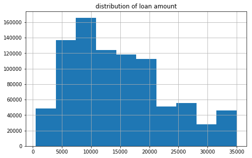

```python
# Here we make the graph for cheking the history of a purticular loan amount column.

#Import materplot library for making the graph
import matplotlib.pyplot as plt
%matplotlib inline

# Figsize is creates an inch-by-inch image, which will be 80-by-80 pixels unless you also give a different dpi argument.
plt.rc("figure", figsize=(8, 5))

#hist is a function in numpy module which helping us to creating the histogram of a column
loan["loan_amnt"].hist()

# Setting the title
plt.title("distribution of loan amount")
```

```python
# Here we take a group by of addr_state for checking the count of a purticular columns.
loan.groupby("addr_state").count()
# This simply says CA state have more loan holder .
```

[output not shown]

```python
# Here we take a group by of addr_state for checking the count of a purticular columns and take id column.
df_group = loan.groupby('addr_state', as_index=False)['id'].count()
```

```python
# Now Sort the Values of id column in asecending order
df_group.sort_values(['id'], ascending=[True], inplace=True)
# Resetting index
df_group = df_group.reset_index(drop=True)
```

# Here we see in the graph State CA have more people

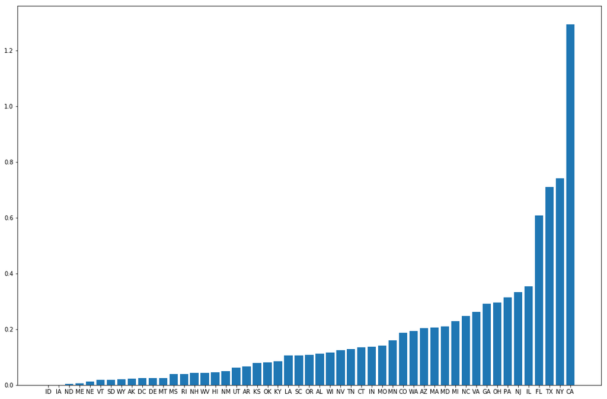

```python
# Creating Bar chart in Index and id columns
plt.bar(df_group.index,df_group.id/100000)
# Creating X Sticks for this graph
plt.xticks(df_group.index,df_group.addr_state)
N = 3
params = plt.gcf()

#Ploat size is taking in inches
plSize = params.get_size_inches()
params.set_size_inches( (plSize[0]*N, plSize[1]*N) )
# showing the plot
plt.show()
```

### Here we represent state wise income, where we see DC state have more income people

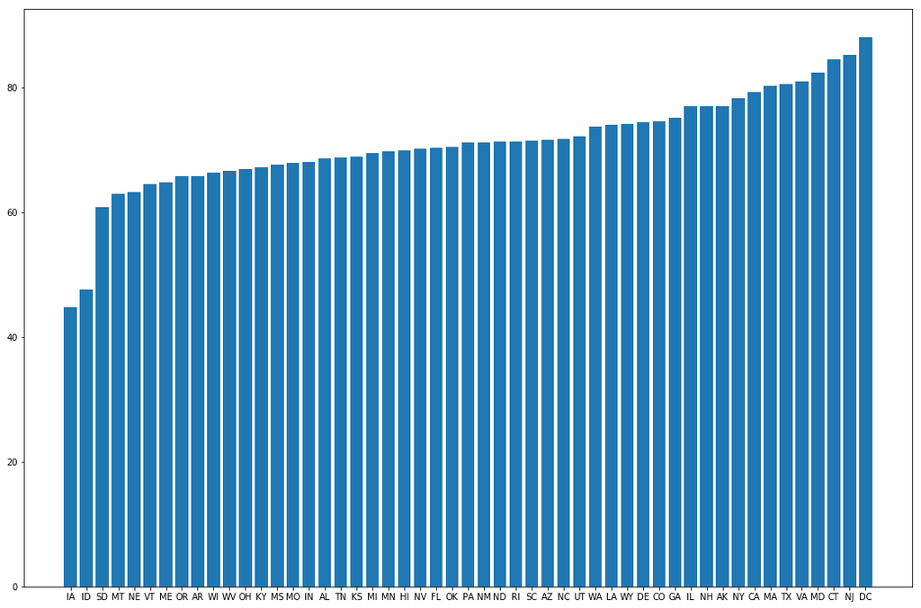

```python
# Now we take mean of Address State columns for showing the annual income
df_group = loan.groupby('addr_state', as_index=False).mean()

# Taking annual income data and apply sorting in ascending order
df_group.sort_values(['annual_inc'], ascending=[True], inplace=True)

#resetting indexing
df_group = df_group.reset_index(drop=True)

#creating Bar chart
plt.bar(df_group.index,df_group.annual_inc/1000)

#Making X sticks for making the group and index
plt.xticks(df_group.index,df_group.addr_state)
N = 3
params = plt.gcf()
plSize = params.get_size_inches()
params.set_size_inches( (plSize[0]*N, plSize[1]*N) )
# Visuakize the plots
plt.show()

# This help us to finding the loan holder
```

# Here we see grade wise interest rate, G grade people may give more interest rate

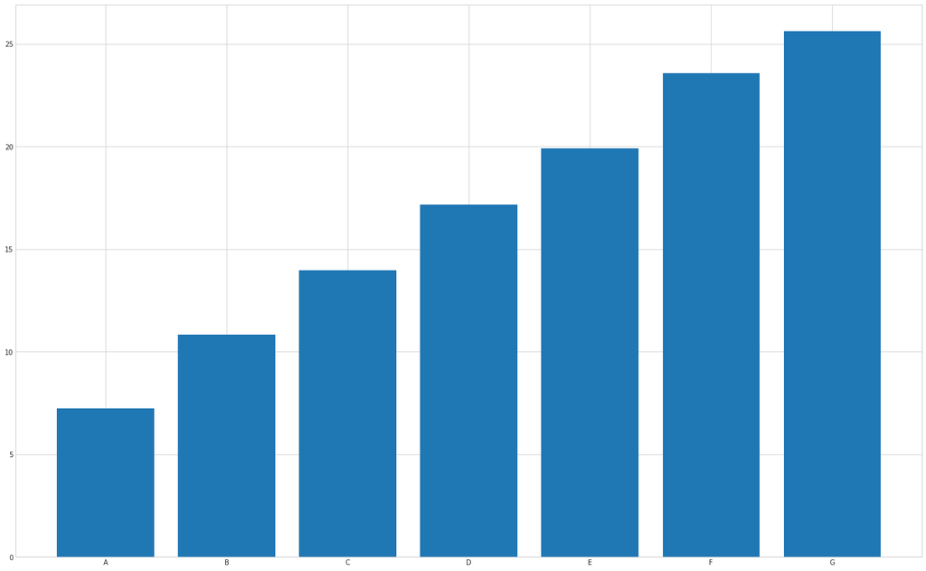

```python
# Now we take mean of grade columns for showing the int_rate
df_group = loan.groupby('grade', as_index=False).mean()

#This will show the intrest rate and order is ascending
df_group.sort_values(['int_rate'], ascending=[True], inplace=True)
df_group = df_group.reset_index(drop=True)
#Ploting the grade Bars
plt.bar(df_group.index,df_group.int_rate,align="center")
plt.xticks(df_group.index,df_group.grade)
N = 3
params = plt.gcf()
plSize = params.get_size_inches()
params.set_size_inches( (plSize[0]*N, plSize[1]*N) )

#Print Plots
plt.show()
```

```python
#Here we take group by interest rate for counting the numbers
loan.groupby("int_rate").count()
```

| int_rate | id | member_id | loan_amnt | funded_amnt | funded_amnt_inv | term | installment | grade | sub_grade | emp_title | ... | total_bal_il | il_util | open_rv_12m | open_rv_24m | max_bal_bc | all_util | total_rev_hi_lim | inq_fi | total_cu_tl | inq_last_12m |
| --- | --- | --- | --- | --- | --- | --- | --- | --- | --- | --- | --- | --- | --- | --- | --- | --- | --- | --- | --- | --- | --- |
| 5.32 | 9651 | 9651 | 9651 | 9651 | 9651 | 9651 | 9651 | 9651 | 9651 | 9024 | ... | 830 | 707 | 830 | 830 | 830 | 830 | 9651 | 830 | 830 | 830 |
| 5.42 | 573 | 573 | 573 | 573 | 573 | 573 | 573 | 573 | 573 | 507 | ... | 0 | 0 | 0 | 0 | 0 | 0 | 0 | 0 | 0 | 0 |
| 5.79 | 410 | 410 | 410 | 410 | 410 | 410 | 410 | 410 | 410 | 380 | ... | 0 | 0 | 0 | 0 | 0 | 0 | 0 | 0 | 0 | 0 |
| 5.93 | 1812 | 1812 | 1812 | 1812 | 1812 | 1812 | 1812 | 1812 | 1812 | 1730 | ... | 0 | 0 | 0 | 0 | 0 | 0 | 1812 | 0 | 0 | 0 |
| 5.99 | 347 | 347 | 347 | 347 | 347 | 347 | 347 | 347 | 347 | 314 | ... | 0 | 0 | 0 | 0 | 0 | 0 | 0 | 0 | 0 | 0 |
| 6.00 | 123 | 123 | 123 | 123 | 123 | 123 | 123 | 123 | 123 | 122 | ... | 0 | 0 | 0 | 0 | 0 | 0 | 97 | 0 | 0 | 0 |
| 6.03 | 10755 | 10755 | 10755 | 10755 | 10755 | 10755 | 10755 | 10755 | 10755 | 10198 | ... | 0 | 0 | 0 | 0 | 0 | 0 | 9275 | 0 | 0 | 0 |
| 6.17 | 252 | 252 | 252 | 252 | 252 | 252 | 252 | 252 | 252 | 231 | ... | 0 | 0 | 0 | 0 | 0 | 0 | 0 | 0 | 0 | 0 |
| 6.24 | 7470 | 7470 | 7470 | 7470 | 7470 | 7470 | 7470 | 7470 | 7470 | 7052 | ... | 359 | 303 | 359 | 359 | 359 | 359 | 7470 | 359 | 359 | 359 |
| 6.39 | 2675 | 2675 | 2675 | 2675 | 2675 | 2675 | 2675 | 2675 | 2675 | 2540 | ... | 0 | 0 | 0 | 0 | 0 | 0 | 2617 | 0 | 0 | 0 |
| 6.49 | 5468 | 5468 | 5468 | 5468 | 5468 | 5468 | 5468 | 5468 | 5468 | 5255 | ... | 210 | 185 | 210 | 210 | 210 | 210 | 5468 | 210 | 210 | 210 |
| 6.54 | 307 | 307 | 307 | 307 | 307 | 307 | 307 | 307 | 307 | 297 | ... | 0 | 0 | 0 | 0 | 0 | 0 | 0 | 0 | 0 | 0 |
| 6.62 | 5409 | 5409 | 5409 | 5409 | 5409 | 5409 | 5409 | 5409 | 5409 | 5052 | ... | 0 | 0 | 0 | 0 | 0 | 0 | 3937 | 0 | 0 | 0 |
| 6.68 | 2471 | 2471 | 2471 | 2471 | 2471 | 2471 | 2471 | 2471 | 2471 | 2389 | ... | 0 | 0 | 0 | 0 | 0 | 0 | 2471 | 0 | 0 | 0 |
| 6.76 | 168 | 168 | 168 | 168 | 168 | 168 | 168 | 168 | 168 | 154 | ... | 0 | 0 | 0 | 0 | 0 | 0 | 0 | 0 | 0 | 0 |
| 6.89 | 7012 | 7012 | 7012 | 7012 | 7012 | 7012 | 7012 | 7012 | 7012 | 6631 | ... | 352 | 293 | 352 | 352 | 352 | 352 | 7012 | 352 | 352 | 352 |
| 6.91 | 310 | 310 | 310 | 310 | 310 | 310 | 310 | 310 | 310 | 289 | ... | 0 | 0 | 0 | 0 | 0 | 0 | 0 | 0 | 0 | 0 |
| 6.92 | 4274 | 4274 | 4274 | 4274 | 4274 | 4274 | 4274 | 4274 | 4274 | 4050 | ... | 0 | 0 | 0 | 0 | 0 | 0 | 4070 | 0 | 0 | 0 |
| 6.97 | 397 | 397 | 397 | 397 | 397 | 397 | 397 | 397 | 397 | 365 | ... | 0 | 0 | 0 | 0 | 0 | 0 | 397 | 0 | 0 | 0 |
| 6.99 | 2597 | 2597 | 2597 | 2597 | 2597 | 2597 | 2597 | 2597 | 2597 | 2462 | ... | 194 | 164 | 194 | 194 | 194 | 194 | 2261 | 194 | 194 | 194 |
| 7.05 | 23 | 23 | 23 | 23 | 23 | 23 | 23 | 23 | 23 | 20 | ... | 0 | 0 | 0 | 0 | 0 | 0 | 0 | 0 | 0 | 0 |
| 7.12 | 3064 | 3064 | 3064 | 3064 | 3064 | 3064 | 3064 | 3064 | 3064 | 2924 | ... | 0 | 0 | 0 | 0 | 0 | 0 | 3055 | 0 | 0 | 0 |
| 7.14 | 342 | 342 | 342 | 342 | 342 | 342 | 342 | 342 | 342 | 318 | ... | 0 | 0 | 0 | 0 | 0 | 0 | 0 | 0 | 0 | 0 |
| 7.26 | 9438 | 9438 | 9438 | 9438 | 9438 | 9438 | 9438 | 9438 | 9438 | 8898 | ... | 458 | 394 | 458 | 458 | 458 | 458 | 9438 | 458 | 458 | 458 |
| 7.29 | 397 | 397 | 397 | 397 | 397 | 397 | 397 | 397 | 397 | 364 | ... | 0 | 0 | 0 | 0 | 0 | 0 | 0 | 0 | 0 | 0 |
| 7.37 | 32 | 32 | 32 | 32 | 32 | 32 | 32 | 32 | 32 | 32 | ... | 0 | 0 | 0 | 0 | 0 | 0 | 0 | 0 | 0 | 0 |
| 7.40 | 72 | 72 | 72 | 72 | 72 | 72 | 72 | 72 | 72 | 69 | ... | 0 | 0 | 0 | 0 | 0 | 0 | 0 | 0 | 0 | 0 |
| 7.42 | 7 | 7 | 7 | 7 | 7 | 7 | 7 | 7 | 7 | 6 | ... | 0 | 0 | 0 | 0 | 0 | 0 | 0 | 0 | 0 | 0 |
| 7.43 | 33 | 33 | 33 | 33 | 33 | 33 | 33 | 33 | 33 | 27 | ... | 0 | 0 | 0 | 0 | 0 | 0 | 0 | 0 | 0 | 0 |
| 7.49 | 3911 | 3911 | 3911 | 3911 | 3911 | 3911 | 3911 | 3911 | 3911 | 3666 | ... | 241 | 208 | 241 | 241 | 241 | 241 | 3255 | 241 | 241 | 241 |
| ... | ... | ... | ... | ... | ... | ... | ... | ... | ... | ... | ... | ... | ... | ... | ... | ... | ... | ... | ... | ... | ... |
| 24.11 | 8 | 8 | 8 | 8 | 8 | 8 | 8 | 8 | 8 | 8 | ... | 0 | 0 | 0 | 0 | 0 | 0 | 0 | 0 | 0 | 0 |
| 24.20 | 35 | 35 | 35 | 35 | 35 | 35 | 35 | 35 | 35 | 32 | ... | 0 | 0 | 0 | 0 | 0 | 0 | 0 | 0 | 0 | 0 |
| 24.24 | 34 | 34 | 34 | 34 | 34 | 34 | 34 | 34 | 34 | 31 | ... | 34 | 28 | 34 | 34 | 34 | 34 | 34 | 34 | 34 | 34 |
| 24.33 | 21 | 21 | 21 | 21 | 21 | 21 | 21 | 21 | 21 | 18 | ... | 0 | 0 | 0 | 0 | 0 | 0 | 0 | 0 | 0 | 0 |
| 24.40 | 1 | 1 | 1 | 1 | 1 | 1 | 1 | 1 | 1 | 1 | ... | 0 | 0 | 0 | 0 | 0 | 0 | 0 | 0 | 0 | 0 |
| 24.50 | 2463 | 2463 | 2463 | 2463 | 2463 | 2463 | 2463 | 2463 | 2463 | 2336 | ... | 0 | 0 | 0 | 0 | 0 | 0 | 2463 | 0 | 0 | 0 |
| 24.52 | 6 | 6 | 6 | 6 | 6 | 6 | 6 | 6 | 6 | 6 | ... | 0 | 0 | 0 | 0 | 0 | 0 | 0 | 0 | 0 | 0 |
| 24.59 | 1 | 1 | 1 | 1 | 1 | 1 | 1 | 1 | 1 | 0 | ... | 0 | 0 | 0 | 0 | 0 | 0 | 0 | 0 | 0 | 0 |
| 24.70 | 206 | 206 | 206 | 206 | 206 | 206 | 206 | 206 | 206 | 192 | ... | 0 | 0 | 0 | 0 | 0 | 0 | 189 | 0 | 0 | 0 |
| 24.76 | 6 | 6 | 6 | 6 | 6 | 6 | 6 | 6 | 6 | 6 | ... | 0 | 0 | 0 | 0 | 0 | 0 | 0 | 0 | 0 | 0 |
| 24.83 | 112 | 112 | 112 | 112 | 112 | 112 | 112 | 112 | 112 | 104 | ... | 0 | 0 | 0 | 0 | 0 | 0 | 97 | 0 | 0 | 0 |
| 24.89 | 352 | 352 | 352 | 352 | 352 | 352 | 352 | 352 | 352 | 342 | ... | 0 | 0 | 0 | 0 | 0 | 0 | 333 | 0 | 0 | 0 |
| 24.99 | 2530 | 2530 | 2530 | 2530 | 2530 | 2530 | 2530 | 2530 | 2530 | 2391 | ... | 31 | 30 | 31 | 31 | 31 | 31 | 2530 | 31 | 31 | 31 |
| 25.09 | 14 | 14 | 14 | 14 | 14 | 14 | 14 | 14 | 14 | 14 | ... | 14 | 14 | 14 | 14 | 14 | 14 | 14 | 14 | 14 | 14 |
| 25.28 | 171 | 171 | 171 | 171 | 171 | 171 | 171 | 171 | 171 | 168 | ... | 0 | 0 | 0 | 0 | 0 | 0 | 171 | 0 | 0 | 0 |
| 25.57 | 1216 | 1216 | 1216 | 1216 | 1216 | 1216 | 1216 | 1216 | 1216 | 1161 | ... | 0 | 0 | 0 | 0 | 0 | 0 | 1216 | 0 | 0 | 0 |
| 25.78 | 482 | 482 | 482 | 482 | 482 | 482 | 482 | 482 | 482 | 459 | ... | 0 | 0 | 0 | 0 | 0 | 0 | 482 | 0 | 0 | 0 |
| 25.80 | 1024 | 1024 | 1024 | 1024 | 1024 | 1024 | 1024 | 1024 | 1024 | 969 | ... | 0 | 0 | 0 | 0 | 0 | 0 | 1024 | 0 | 0 | 0 |
| 25.83 | 797 | 797 | 797 | 797 | 797 | 797 | 797 | 797 | 797 | 755 | ... | 0 | 0 | 0 | 0 | 0 | 0 | 797 | 0 | 0 | 0 |
| 25.89 | 599 | 599 | 599 | 599 | 599 | 599 | 599 | 599 | 599 | 566 | ... | 0 | 0 | 0 | 0 | 0 | 0 | 599 | 0 | 0 | 0 |
| 25.99 | 549 | 549 | 549 | 549 | 549 | 549 | 549 | 549 | 549 | 520 | ... | 32 | 27 | 32 | 32 | 32 | 32 | 549 | 32 | 32 | 32 |
| 26.06 | 356 | 356 | 356 | 356 | 356 | 356 | 356 | 356 | 356 | 340 | ... | 13 | 13 | 13 | 13 | 13 | 13 | 356 | 13 | 13 | 13 |
| 26.77 | 443 | 443 | 443 | 443 | 443 | 443 | 443 | 443 | 443 | 417 | ... | 18 | 17 | 18 | 18 | 18 | 18 | 443 | 18 | 18 | 18 |
| 26.99 | 10 | 10 | 10 | 10 | 10 | 10 | 10 | 10 | 10 | 10 | ... | 10 | 10 | 10 | 10 | 10 | 10 | 10 | 10 | 10 | 10 |
| 27.31 | 347 | 347 | 347 | 347 | 347 | 347 | 347 | 347 | 347 | 332 | ... | 24 | 21 | 24 | 24 | 24 | 24 | 347 | 24 | 24 | 24 |
| 27.49 | 7 | 7 | 7 | 7 | 7 | 7 | 7 | 7 | 7 | 7 | ... | 7 | 7 | 7 | 7 | 7 | 7 | 7 | 7 | 7 | 7 |
| 27.88 | 222 | 222 | 222 | 222 | 222 | 222 | 222 | 222 | 222 | 209 | ... | 10 | 9 | 10 | 10 | 10 | 10 | 222 | 10 | 10 | 10 |
| 27.99 | 5 | 5 | 5 | 5 | 5 | 5 | 5 | 5 | 5 | 5 | ... | 5 | 5 | 5 | 5 | 5 | 5 | 5 | 5 | 5 | 5 |
| 28.49 | 139 | 139 | 139 | 139 | 139 | 139 | 139 | 139 | 139 | 136 | ... | 6 | 6 | 6 | 6 | 6 | 6 | 139 | 6 | 6 | 6 |
| 28.99 | 112 | 112 | 112 | 112 | 112 | 112 | 112 | 112 | 112 | 110 | ... | 8 | 8 | 8 | 8 | 8 | 8 | 112 | 8 | 8 | 8 |

542 rows × 73 columns

### Here we see the distribution of Interest rate where we see 10-15% is standerd Interest rate

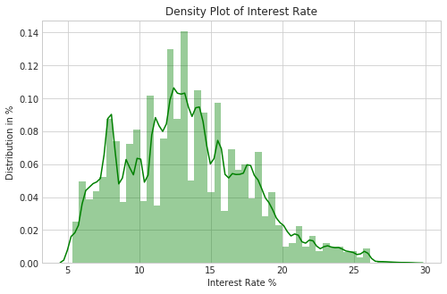

```python
import warnings # ignore warnings
warnings.filterwarnings("ignore")
import seaborn as sns

# Density Distribution of Interest Rate
sns.set_style("whitegrid")
ax=sns.distplot(loan.int_rate, color="g")
ax.set(xlabel='Interest Rate %',
       ylabel='Distribution in %',title='Density Plot of Interest Rate')

plt.legend();

#This shows the density plot on behalf of interst rate
```

### Here we see grade wise interest rate where we analysis than lower grade have lower interest rate and in above graph we also see B grade member give approx 10-15% interest rate

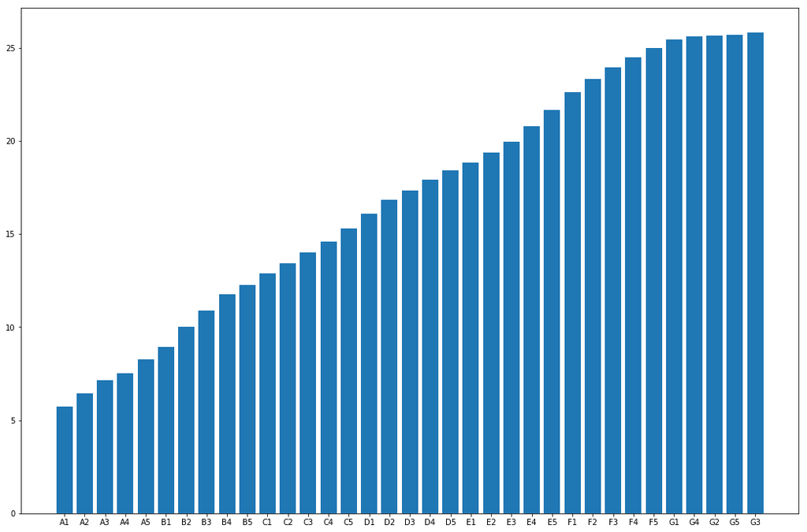

```python
#A plot of sub grade and rate shows that they are also correlated
df_group = loan.groupby('sub_grade', as_index=False).mean()
df_group.sort_values(['int_rate'], ascending=[True], inplace=True)
df_group = df_group.reset_index(drop=True)
plt.bar(df_group.index,df_group.int_rate,align="center")
plt.xticks(df_group.index,df_group.sub_grade)
N = 3
params = plt.gcf()
plSize = params.get_size_inches()
params.set_size_inches( (plSize[0]*N, plSize[1]*N) )
plt.show()
```

### Here we see B grade have more number of people. Grade is decided on behalf of Credit score and income. Here also we represent count on grade

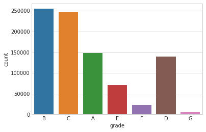

```python
sns.countplot(loan['grade'])
```

##### Here we see more than 50% people pay loan amount in 3 years

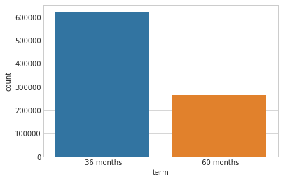

```python
sns.countplot(loan['term'])
```

```python
loan_status_distribution=pd.DataFrame(loan['loan_status'].value_counts())
loan_status_distribution.reset_index(inplace=True)
loan_status_distribution.columns=['Loan_Status_Category','Number of applicants']
loan_status_distribution
```

|  | Loan_Status_Category | Number of applicants |
| --- | --- | --- |
| 0 | Current | 601779 |
| 1 | Fully Paid | 207723 |
| 2 | Charged Off | 45248 |
| 3 | Late (31-120 days) | 11591 |
| 4 | Issued | 8460 |
| 5 | In Grace Period | 6253 |
| 6 | Late (16-30 days) | 2357 |
| 7 | Does not meet the credit policy. Status:Fully ... | 1988 |
| 8 | Default | 1219 |
| 9 | Does not meet the credit policy. Status:Charge... | 761 |